# Seminarska naloga

Viri podatkov

Urh Peček in Alen Kahteran

7. 5. 2020

V tej nalogi bo predstavljeno nekaj pogledov o raku na debelem črevu, rektumu in rektosigmoidni zvezi. Podatki so pridobljeni na spletni strani SLORA (Slovenija in rak - Register raka republike Slovenije).

Pri večini grafov, kjer je le lahko, je prikazana groba stopnja saj je bolj primerljiva med starostnimi skupinami, upravnimi enotami, spolu, itd. saj so te mere tako normalizirane. Groba stopnja je podatek o številu novih primerov bolezni ali številu umrlih, preračunana na 100.000 oseb opazovane populacije.

# Incidenca

Incidenca pomeni absolutno število vseh na novo ugotovljenih primerov neke bolezni (v našem primeru raka) v točno določeni populaciji v enem koledarskem letu. Ker incidenca ne šteje bolnikov, pač pa primere bolezni, lahko posamezna oseba, če v istem letu zboli za različnimi rakavimi boleznimi, prispeva v incidenco več primerov bolezni. V incidenco raka ne štejemo novih primarnih rakov parnega organa iste lokacije, če je bila histološka vrsta obeh rakov, npr. leve in desne dojke, enaka. Prav tako v incidenco ne štejemo novega pojava raka iste histološke vrste na istem organu, npr. multiple lezije v debelem črevesu.

## Osnovni pogled

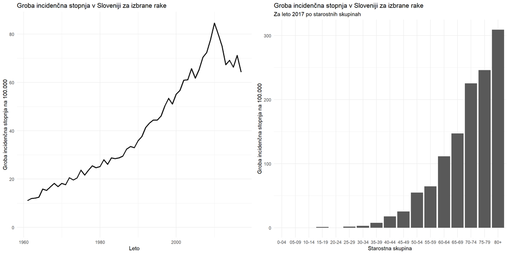

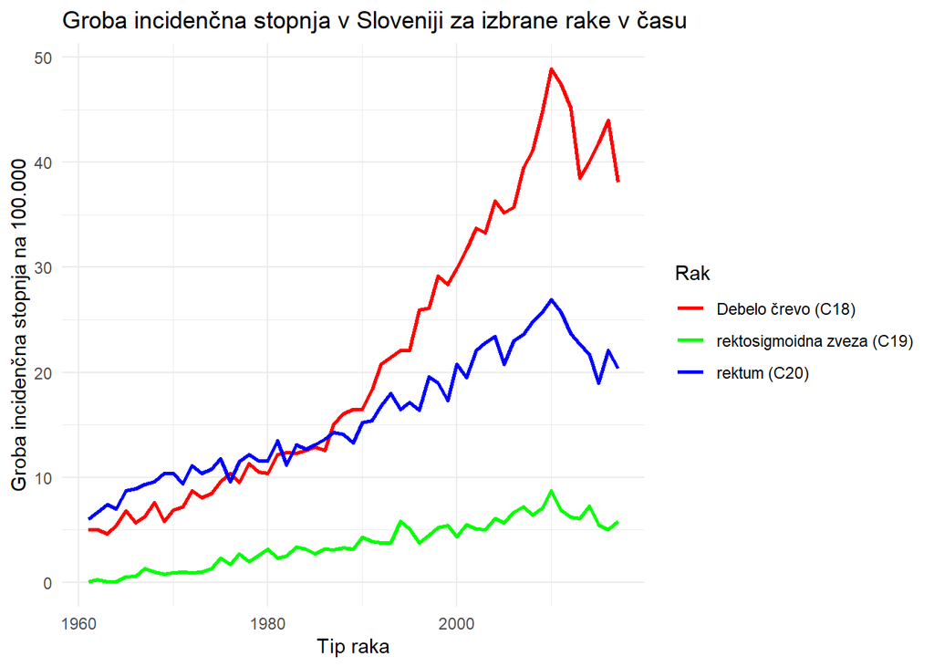

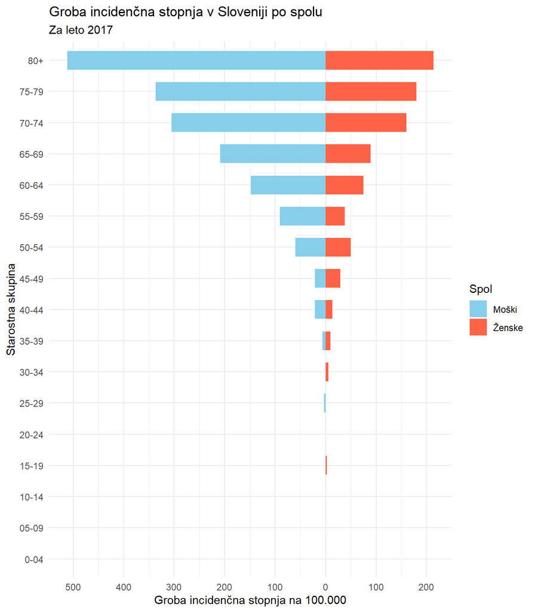

Starostno standardizirana stopnja je teoretična stopnja, pri kateri predpostavimo, da je starostna struktura opazovane populacije taka kot v standardni populaciji – pove nam torej kakšna bi bila groba stopnja v opazovani populaciji, če bi bila starostna struktura te populacije enaka kot je v standardni populaciji.

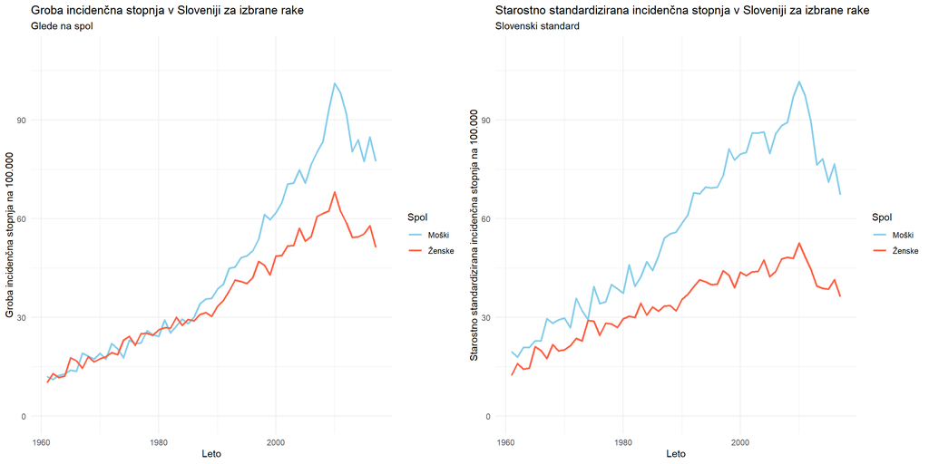

## Dodatna vizualizacija

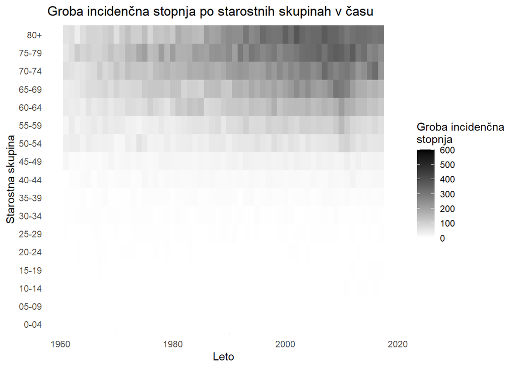

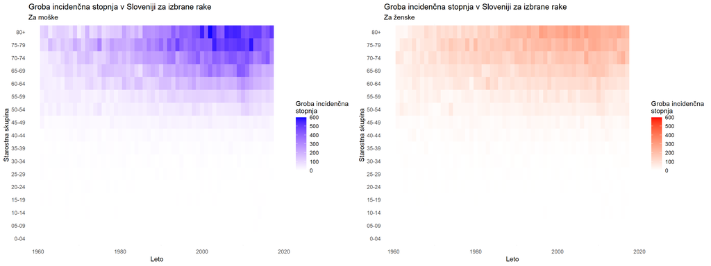

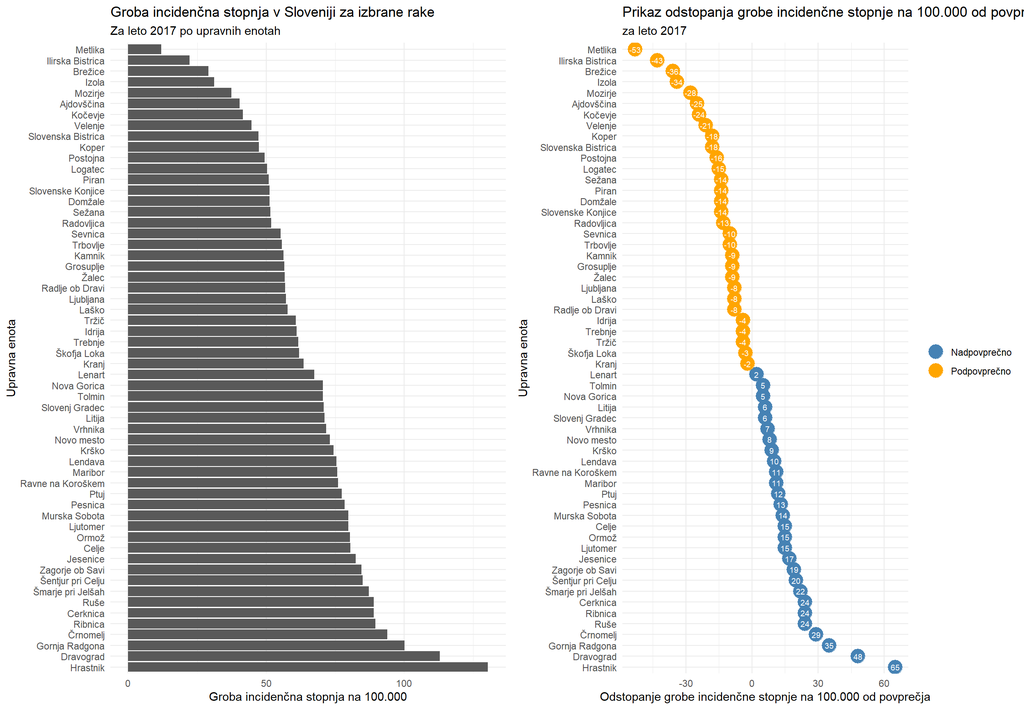

# Umrljivost

Z umrljivostjo izrazimo absolutno število vseh umrlih za določeno boleznijo v točno določeni populaciji v enem koledarskem letu.

## Osnovni pogled

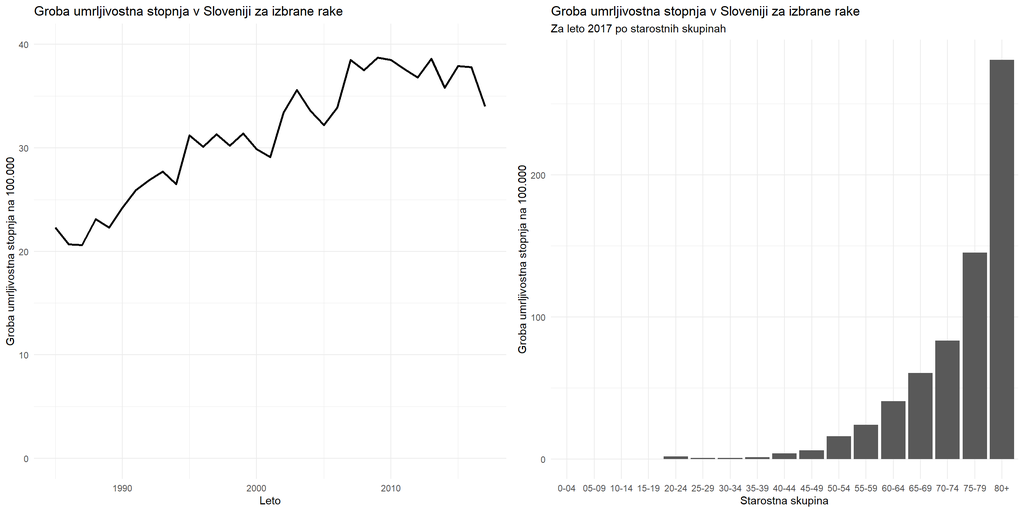

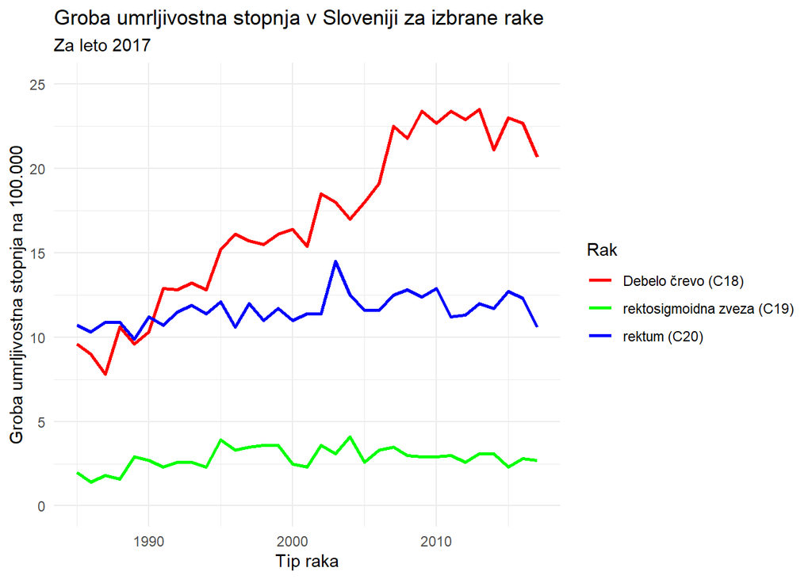

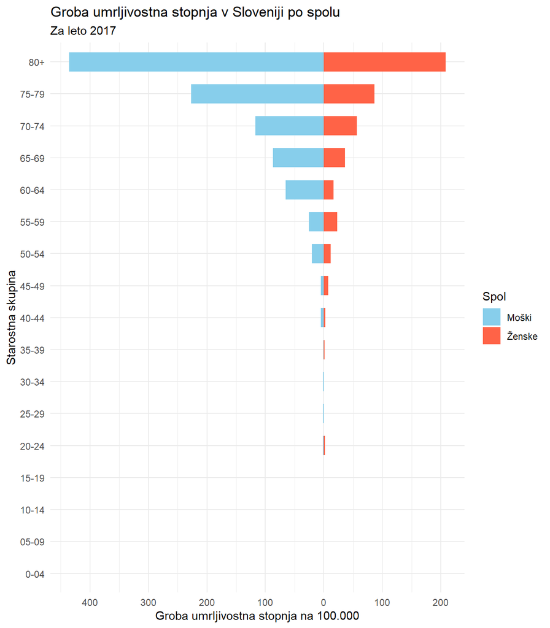

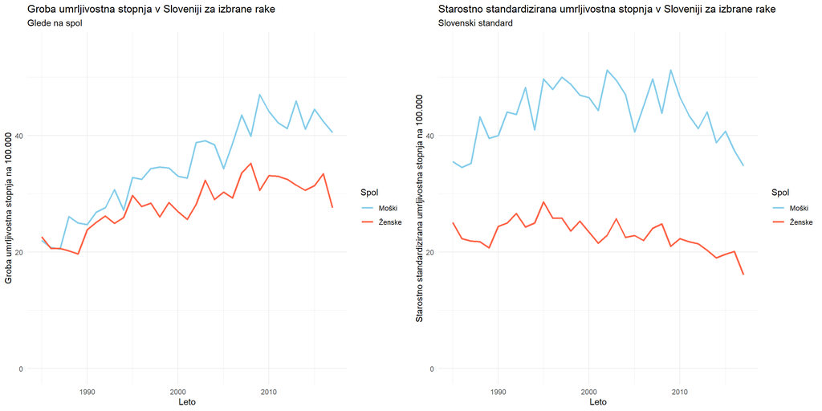

## Dodatna vizualizacija

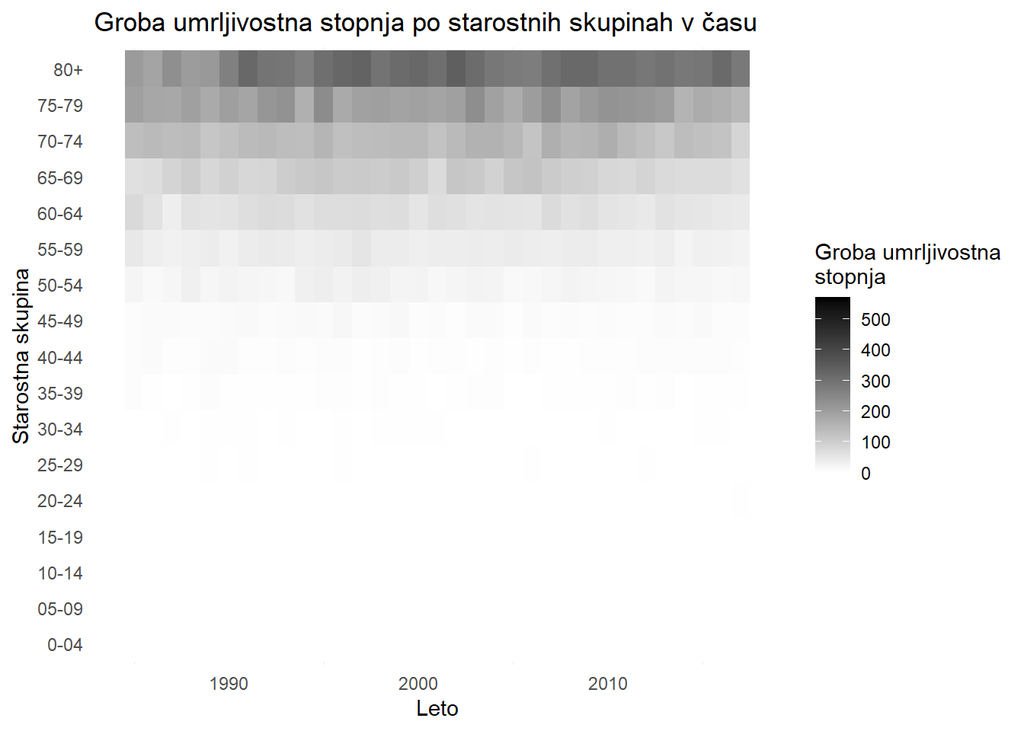

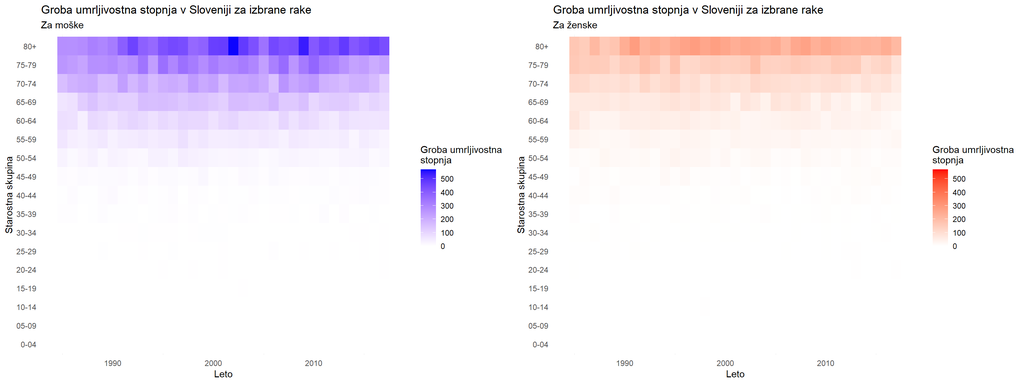

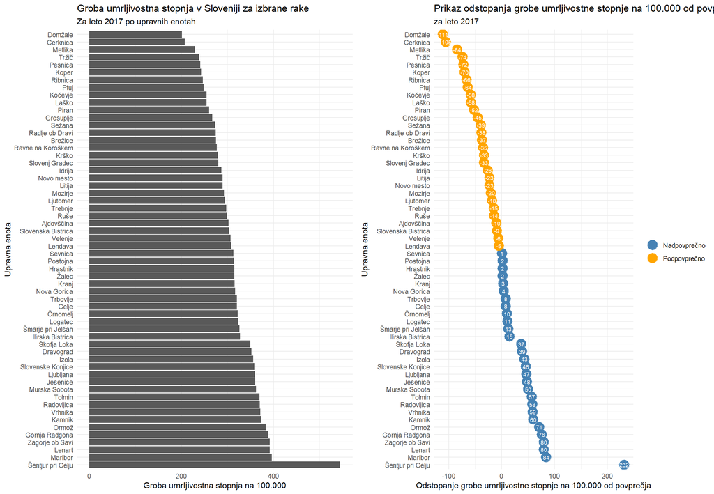

# Preživetje

Preživetje predstavlja delež bolnikov, ki so po izbranem obdobju od postavitve diagnoze še živi. Preživetje bolnikov z rakom običajno opazujemo po enem, treh, petih in desetih letih po diagnozi. V našem primeru si bomo ogledali relativno preživetje ki je razmerje med opazovanim in pričakovanim preživetjem, t.j. preživetjem, ki ga glede na spol in starost v določenem obdobju pričakujemo v celotni populaciji, iz katere prihajajo bolniki.

## Relativno preživetje

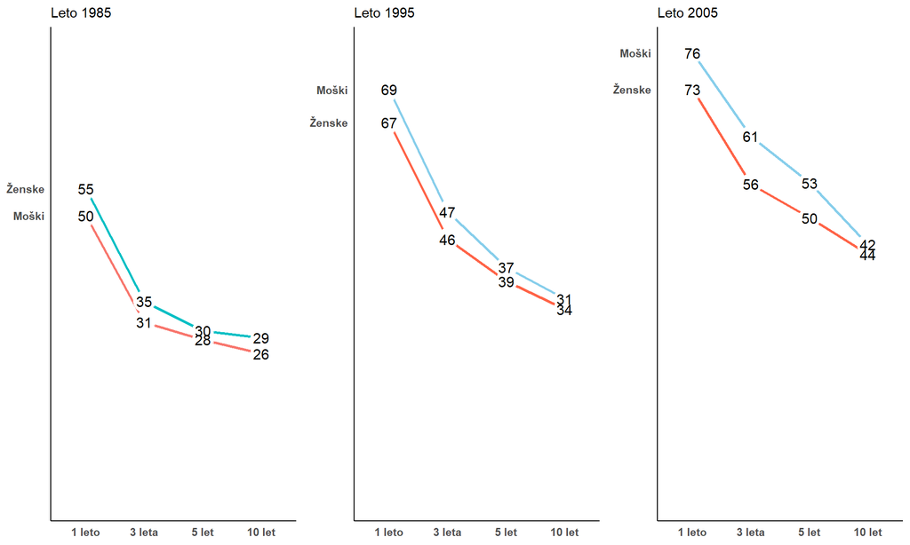